# Paired comparison and graded response models for LLM agent evaluation

Bradley-Terry models, Bayesian ordinal regression and cosine similarity plots

Author

Affiliation

David Selby

[DFKI](https://www.dfki.de)

Published

August 1, 2025

# Introduction

This document is a supplement to the “BioDisco” paper. It is used to generate the figures and tables for the evaluation section of the paper.

## Requirements

For this analysis we need the following packages:

```r
library(BradleyTerry2) # For modelling. Includes {qvcalc}
library(dplyr) # For data manipulation
library(tidyr) # For data reshaping
library(ggplot2) # For plotting
library(knitr) # For compilation & tables
library(purrr) # For functional programming
library(kableExtra)
theme_set(
    theme_bw(base_family = "Helvetica") +
        theme(
            panel.grid = element_blank(), # remove gridlines
            strip.background = element_blank() # remove shading from facet labels
        )
)
library(likert) # For visualizing Likert scales
library(brms) # For Bayesian modelling
library(tidybayes) # For inference with fitted Bayesian models
```

# Paired comparison modelling

The data files contain the results from paired comparisons of LLMs evaluated on various metrics. At the time of rendering, available files are as follows:

```r
list.files("data")
```

```
[1] "CVD_raw_scores.csv"            "Immunology_raw_scores.csv"
[3] "results_for_BT copy.csv"       "results_for_BT_final.csv"
[5] "results_for_BT_new_prompt.csv" "results_for_BT_testing.csv"
[7] "results_for_BT.csv"            "temporal-eval.csv"
```

```r
results <- read.csv("data/results_for_BT_new_prompt.csv")
head(results) |> kable()
```

| score | P1 | P2 | P1_win | P2_win | Tie |
| --- | --- | --- | --- | --- | --- |
| novelty | Single LLM | Multi-agent | 8 | 86 | 6 |
| novelty | Single LLM | Multi+Refine | 0 | 100 | 0 |
| novelty | Single LLM | Multi+Tools | 1 | 99 | 0 |
| novelty | Single LLM | BioDisco | 0 | 100 | 0 |
| novelty | Multi-agent | Multi+Refine | 10 | 89 | 1 |
| novelty | Multi-agent | Multi+Tools | 6 | 94 | 0 |

## Data wrangling

```r
all_players <- union(results$P1, results$P2)
results$P1 <- factor(results$P1, levels = all_players)
results$P2 <- factor(results$P2, levels = all_players)
```

```r
fit_bradley_terry <- function(data, home_adv = FALSE, bias_reduced = FALSE) {
    data_for_model <- data %>%
        mutate(
            P1_win = P1_win + 0.5 * Tie,
            P2_win = P2_win + 0.5 * Tie
        )

    # Create player objects based on whether home_adv is included
    if (home_adv) {
        P1_obj <- data.frame(team = data_for_model$P1, home_adv = 1)
        P2_obj <- data.frame(team = data_for_model$P2, home_adv = 0)
        bt_formula <- ~ team + home_adv
    } else {
        P1_obj <- data.frame(team = data_for_model$P1)
        P2_obj <- data.frame(team = data_for_model$P2)
        bt_formula <- ~team
    }

    model <- BradleyTerry2::BTm(
        cbind(P1_win, P2_win),
        P1_obj, # Use the created player objects
        P2_obj, # Use the created player objects
        data = data_for_model,
        formula = bt_formula, # Use the dynamic formula
        family = binomial,
        br = bias_reduced,
        id = "team" # 'id' should refer to the column that identifies players/teams
    )

    model
}

fit_to_subset <- function(metric, data, ...) {
    subset_data <- filter(data, score == metric)
    fit_bradley_terry(subset_data, ...)
}

centre_scores <- function(model) {
    coefs <- coef(model)

    # Get player ability scores
    player_coefs <- coefs[grep("^team", names(coefs), value = TRUE)]
    # Get home-advantage coefficient if it exists
    home_adv_coef <- coefs["home_adv"]
    if (is.na(home_adv_coef)) {
        home_adv_coef <- NULL
    }

    player_scores <- setNames(c(0, player_coefs), all_players)
    player_scores <- player_scores - mean(player_scores)

    c(player_scores, home_adv = home_adv_coef)
}

get_quasi_variances <- function(model) {
    estimates <- centre_scores(model)[all_players]
    qv <- qvcalc::qvcalc(
        model,
        coef.indices = seq_along(all_players) - 1,
        estimate = estimates
    )
    # rownames(qv) <- NULL
    qv$qvframe$rowname <- all_players
    qv$qvframe$estimate <- estimates
    qv$qvframe <- relocate(qv$qvframe, rowname)
    qv
}
```

The following functions provide visualizations of the resulting plots and quasi-variance approximations.

```r
centipede_plot <- function(qv_frame) {
    qv_df <- map_dfr(qv_list, "qvframe", .id = "metric") %>%
        # map_dfr(tibble::rownames_to_column, .id = "metric") %>%
        filter(rowname != "home_adv")

    ggplot(qv_df) +
        aes(
            forcats::fct_reorder(rowname, estimate),
            estimate,
            ymin = estimate - 1.96 * quasiSE,
            ymax = estimate + 1.96 * quasiSE
        ) +
        geom_linerange(alpha = .5) +
        geom_point() +
        coord_flip() +
        facet_wrap(~metric, scales = "free_x") +
        labs(x = NULL, y = "Ability score") +
        theme(
            strip.background = element_blank(),
            plot.margin = margin(0, 5, 0, 0),
            # text = element_text(family = "Times New Roman")
        )
}


beeswarm_plot <- function(qv_list) {
    relative_errors <- map(qv_list, "relerrs")
    data <- purrr::map_dfr(relative_errors, stack, .id = "metric") # values, ind

    ggplot(data) +
        aes(x = metric, y = values) +
        ggbeeswarm::geom_quasirandom() +
        labs(x = NULL, y = "Relative error") +
        coord_flip()
}
```

## Results

### With home advantage coefficient

Fit the model to the data.

```r
metrics <- unique(results$score) %>% setNames(., .)
bt_models <- map(metrics, fit_to_subset, data = results, home_adv = TRUE)
qv_list <- map(bt_models, get_quasi_variances)
```

Present some summary statistics of the fitted models.

```r
library(broom)
map_dfr(bt_models, broom::tidy, .id = "metric") |>
    kable()
```

Summary of Bradley-Terry models for each metric

| metric | term | estimate | std.error | statistic | p.value |
| --- | --- | --- | --- | --- | --- |
| novelty | teamMulti-agent | 2.8985177 | 0.4482469 | 6.4663416 | 0.0000000 |
| novelty | teamMulti+Refine | 5.8221805 | 0.6733227 | 8.6469390 | 0.0000000 |
| novelty | teamMulti+Tools | 6.4027395 | 0.9113220 | 7.0257708 | 0.0000000 |
| novelty | teamBioDisco | 9.0899822 | 1.1560232 | 7.8631487 | 0.0000000 |
| novelty | home_adv | 0.8026602 | 0.3604814 | 2.2266342 | 0.0259717 |
| relevance | teamMulti-agent | -0.0946304 | 0.1399995 | -0.6759339 | 0.4990826 |
| relevance | teamMulti+Refine | -0.3874814 | 0.1715601 | -2.2585749 | 0.0239098 |
| relevance | teamMulti+Tools | -0.0855453 | 0.2138123 | -0.4000953 | 0.6890863 |
| relevance | teamBioDisco | -0.2764607 | 0.2623261 | -1.0538820 | 0.2919369 |
| relevance | home_adv | 0.0771199 | 0.1428515 | 0.5398608 | 0.5892931 |
| significance | teamMulti-agent | 1.5425902 | 0.2670156 | 5.7771539 | 0.0000000 |
| significance | teamMulti+Refine | 2.6454052 | 0.3782274 | 6.9942183 | 0.0000000 |
| significance | teamMulti+Tools | 3.7037721 | 0.4994204 | 7.4161404 | 0.0000000 |
| significance | teamBioDisco | 4.9452247 | 0.6586507 | 7.5081144 | 0.0000000 |
| significance | home_adv | 0.0676008 | 0.2400569 | 0.2816033 | 0.7782477 |
| verifiability | teamMulti-agent | 0.1024227 | 0.1510424 | 0.6781058 | 0.4977046 |
| verifiability | teamMulti+Refine | -0.6218918 | 0.1784806 | -3.4843660 | 0.0004933 |
| verifiability | teamMulti+Tools | -0.5711104 | 0.2250495 | -2.5377101 | 0.0111580 |
| verifiability | teamBioDisco | -0.1385173 | 0.2753485 | -0.5030618 | 0.6149208 |
| verifiability | home_adv | 0.4392820 | 0.1491073 | 2.9460804 | 0.0032183 |

```r
map_dfr(bt_models, broom::tidy, .id = "metric") |>
    filter(term == "home_adv") |>
    # rename_with(tools::toTitleCase) |>
    kable("latex", booktabs = TRUE, digits = 2) %>%
    # collapse_rows(valign = "top") %>%
    cat()
```

```
\begin{table}

\caption{\label{tab:model summary}Summary of Bradley-Terry models for each metric}
\centering
\begin{tabular}[t]{llrrrr}
\toprule
metric & term & estimate & std.error & statistic & p.value\\
\midrule
novelty & home\_adv & 0.80 & 0.36 & 2.23 & 0.03\\
relevance & home\_adv & 0.08 & 0.14 & 0.54 & 0.59\\
significance & home\_adv & 0.07 & 0.24 & 0.28 & 0.78\\
verifiability & home\_adv & 0.44 & 0.15 & 2.95 & 0.00\\
\bottomrule
\end{tabular}
\end{table}
```

Make a centipede plot of the results.

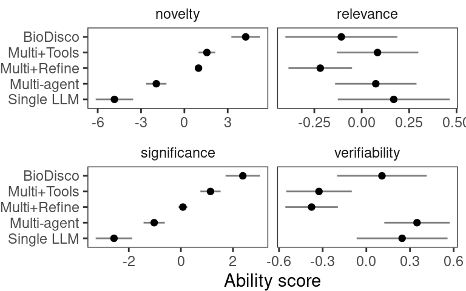

Centipede plot of Bradley-Terry model scores for each metric

```r
centipede_plot(qv_list)
```

Make a table of tables.

```r
library(kableExtra)
qv_tbl <- qv_list %>%
    map_dfr("qvframe", .id = "metric") %>%
    as_tibble() %>%
    rename(model = rowname) %>%
    # mutate(metric = tools::toTitleCase(metric)) %>%
    rename_with(tools::toTitleCase)

qv_tbl %>%
    kable(digits = 2)
```

Quasi-variance and point estimates for each metric

| Metric | Model | Estimate | SE | quasiSE | quasiVar |
| --- | --- | --- | --- | --- | --- |
| novelty | Single LLM | -4.84 | 0.00 | 0.66 | 0.44 |
| novelty | Multi-agent | -1.94 | 0.45 | 0.36 | 0.13 |
| novelty | Multi+Refine | 0.98 | 0.67 | 0.10 | 0.01 |
| novelty | Multi+Tools | 1.56 | 0.91 | 0.30 | 0.09 |
| novelty | BioDisco | 4.25 | 1.16 | 0.51 | 0.26 |
| relevance | Single LLM | 0.17 | 0.00 | 0.15 | 0.02 |
| relevance | Multi-agent | 0.07 | 0.14 | 0.11 | 0.01 |
| relevance | Multi+Refine | -0.22 | 0.17 | 0.09 | 0.01 |
| relevance | Multi+Tools | 0.08 | 0.21 | 0.11 | 0.01 |
| relevance | BioDisco | -0.11 | 0.26 | 0.15 | 0.02 |
| significance | Single LLM | -2.57 | 0.00 | 0.36 | 0.13 |
| significance | Multi-agent | -1.02 | 0.27 | 0.21 | 0.04 |
| significance | Multi+Refine | 0.08 | 0.38 | 0.09 | 0.01 |
| significance | Multi+Tools | 1.14 | 0.50 | 0.20 | 0.04 |
| significance | BioDisco | 2.38 | 0.66 | 0.34 | 0.11 |
| verifiability | Single LLM | 0.25 | 0.00 | 0.16 | 0.03 |
| verifiability | Multi-agent | 0.35 | 0.15 | 0.11 | 0.01 |
| verifiability | Multi+Refine | -0.38 | 0.18 | 0.09 | 0.01 |
| verifiability | Multi+Tools | -0.33 | 0.23 | 0.11 | 0.01 |
| verifiability | BioDisco | 0.11 | 0.28 | 0.16 | 0.02 |

```r
qv_tbl %>%
    kable("latex", booktabs = TRUE, digits = 2) %>%
    collapse_rows(valign = "top") %>%
    cat()
```

```
\begin{table}

\caption{\label{tab:qv table}Quasi-variance and point estimates for each metric}
\centering
\begin{tabular}[t]{llrrrr}
\toprule
Metric & Model & Estimate & SE & quasiSE & quasiVar\\
\midrule
 & Single LLM & -4.84 & 0.00 & 0.66 & 0.44\\
\cmidrule{2-6}
 & Multi-agent & -1.94 & 0.45 & 0.36 & 0.13\\
\cmidrule{2-6}
 & Multi+Refine & 0.98 & 0.67 & 0.10 & 0.01\\
\cmidrule{2-6}
 & Multi+Tools & 1.56 & 0.91 & 0.30 & 0.09\\
\cmidrule{2-6}
\multirow[t]{-5}{*}[4\dimexpr\aboverulesep+\belowrulesep+\cmidrulewidth]{\raggedright\arraybackslash novelty} & BioDisco & 4.25 & 1.16 & 0.51 & 0.26\\
\cmidrule{1-6}
 & Single LLM & 0.17 & 0.00 & 0.15 & 0.02\\
\cmidrule{2-6}
 & Multi-agent & 0.07 & 0.14 & 0.11 & \\
\cmidrule{2-5}
 & Multi+Refine & -0.22 & 0.17 & 0.09 & \\
\cmidrule{2-5}
 & Multi+Tools & 0.08 & 0.21 & 0.11 & \multirow[t]{-3}{*}{\raggedleft\arraybackslash 0.01}\\
\cmidrule{2-6}
\multirow[t]{-5}{*}[4\dimexpr\aboverulesep+\belowrulesep+\cmidrulewidth]{\raggedright\arraybackslash relevance} & BioDisco & -0.11 & 0.26 & 0.15 & 0.02\\
\cmidrule{1-6}
 & Single LLM & -2.57 & 0.00 & 0.36 & 0.13\\
\cmidrule{2-6}
 & Multi-agent & -1.02 & 0.27 & 0.21 & 0.04\\
\cmidrule{2-6}
 & Multi+Refine & 0.08 & 0.38 & 0.09 & 0.01\\
\cmidrule{2-6}
 & Multi+Tools & 1.14 & 0.50 & 0.20 & 0.04\\
\cmidrule{2-6}
\multirow[t]{-5}{*}[4\dimexpr\aboverulesep+\belowrulesep+\cmidrulewidth]{\raggedright\arraybackslash significance} & BioDisco & 2.38 & 0.66 & 0.34 & 0.11\\
\cmidrule{1-6}
 & Single LLM & 0.25 & 0.00 & 0.16 & 0.03\\
\cmidrule{2-6}
 & Multi-agent & 0.35 & 0.15 & 0.11 & \\
\cmidrule{2-5}
 & Multi+Refine & -0.38 & 0.18 & 0.09 & \\
\cmidrule{2-5}
 & Multi+Tools & -0.33 & 0.23 & 0.11 & \multirow[t]{-3}{*}{\raggedleft\arraybackslash 0.01}\\
\cmidrule{2-6}
\multirow[t]{-5}{*}[4\dimexpr\aboverulesep+\belowrulesep+\cmidrulewidth]{\raggedright\arraybackslash verifiability} & BioDisco & 0.11 & 0.28 & 0.16 & 0.02\\
\bottomrule
\end{tabular}
\end{table}
```

Make a beeswarm plot of the relative errors in the quasi-variance approximation for each metric.

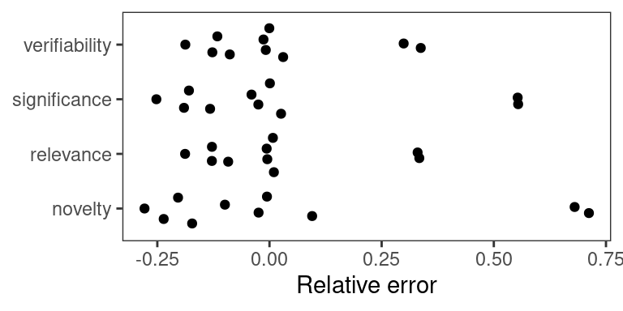

Beeswarm plot of relative errors for each metric

```r
beeswarm_plot(qv_list)
```

### Without home advantage coefficient

Just given for reference. Will require some adjustment to the figure dimensions to make it look good in the PDF.

[figure not shown]

Centipede plot of Bradley-Terry model scores for each metric without home advantage

```r
bt_models2 <- map(metrics, fit_to_subset, data = results, home_adv = FALSE)
qv_list2 <- map(bt_models2, get_quasi_variances)
centipede_plot(qv_list2)
```

Beeswarm and tables:

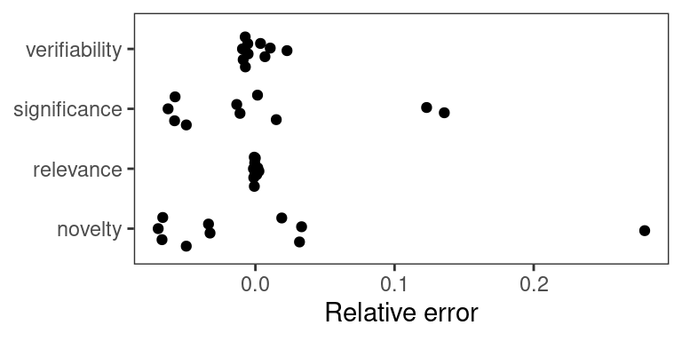

Relative errors for quasi-variance approximation without home advantage

```r
beeswarm_plot(qv_list2)
```

```r
qv_tbl2 <- qv_list2 %>%
    map_dfr("qvframe", .id = "metric") %>%
    as_tibble() %>%
    rename(model = rowname) %>%
    # mutate(metric = tools::toTitleCase(metric)) %>%
    rename_with(tools::toTitleCase)

qv_tbl2 %>%
    kable(digits = 2)
```

| Metric | Model | Estimate | SE | quasiSE | quasiVar |
| --- | --- | --- | --- | --- | --- |
| novelty | Single LLM | -3.67 | 0.00 | 0.32 | 0.11 |
| novelty | Multi-agent | -1.48 | 0.30 | 0.22 | 0.05 |
| novelty | Multi+Refine | 1.00 | 0.37 | 0.12 | 0.02 |
| novelty | Multi+Tools | 0.99 | 0.37 | 0.12 | 0.02 |
| novelty | BioDisco | 3.17 | 0.42 | 0.22 | 0.05 |
| relevance | Single LLM | 0.23 | 0.00 | 0.09 | 0.01 |
| relevance | Multi-agent | 0.10 | 0.13 | 0.09 | 0.01 |
| relevance | Multi+Refine | -0.22 | 0.13 | 0.09 | 0.01 |
| relevance | Multi+Tools | 0.05 | 0.13 | 0.09 | 0.01 |
| relevance | BioDisco | -0.17 | 0.13 | 0.09 | 0.01 |
| significance | Single LLM | -2.48 | 0.00 | 0.20 | 0.04 |
| significance | Multi-agent | -0.99 | 0.21 | 0.13 | 0.02 |
| significance | Multi+Refine | 0.08 | 0.23 | 0.11 | 0.01 |
| significance | Multi+Tools | 1.10 | 0.25 | 0.13 | 0.02 |
| significance | BioDisco | 2.29 | 0.28 | 0.17 | 0.03 |
| verifiability | Single LLM | 0.60 | 0.00 | 0.10 | 0.01 |
| verifiability | Multi-agent | 0.51 | 0.13 | 0.10 | 0.01 |
| verifiability | Multi+Refine | -0.36 | 0.14 | 0.09 | 0.01 |
| verifiability | Multi+Tools | -0.50 | 0.14 | 0.10 | 0.01 |
| verifiability | BioDisco | -0.25 | 0.14 | 0.09 | 0.01 |

```r
qv_tbl2 %>%
    kable("latex", booktabs = TRUE, digits = 2) %>%
    collapse_rows(valign = "top") %>%
    cat()
```

[output not shown]

## Davidson model

**Caution**

A Davidson model was fitted in an earlier version of this document (`pairwise.Rmd`), and may eventually be copied over. However it is not included in the paper.

# Temporal evaluation

We produce a violin plot to compare the gold–gold (unrelated) hypotheses with the gold–generated (paired) hypotheses.

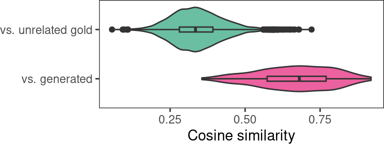

Violin plot of cosine similarities for the temporal evaluation

```r
temporal <- read.csv("data/temporal-eval.csv") %>%
    setNames(c("vs. unrelated gold", "vs. generated")) %>%
    pivot_longer(everything()) %>%
    filter(!is.na(value))

ggplot(temporal, aes(x = name, y = value, fill = name)) +
    geom_violin() +
    geom_boxplot(width = .1) +
    labs(x = NULL, y = "Cosine similarity") +
    theme(legend.position = "none") +
    scale_fill_manual(values = c("#EC619F", "#6ABFA3")) +
    theme(plot.margin = margin(0, 0, 0, 0)) +
    coord_flip()
```

# Human evaluation

The results of the human evaluation survey live in the following files:

```r
human_cvd <- read.csv("data/CVD_raw_scores.csv") |> mutate(topic = "CVD")
human_imm <- read.csv("data/Immunology_raw_scores.csv") |> mutate(topic = "Immunology")
human <- bind_rows(human_cvd, human_imm)
```

Look at correlations.

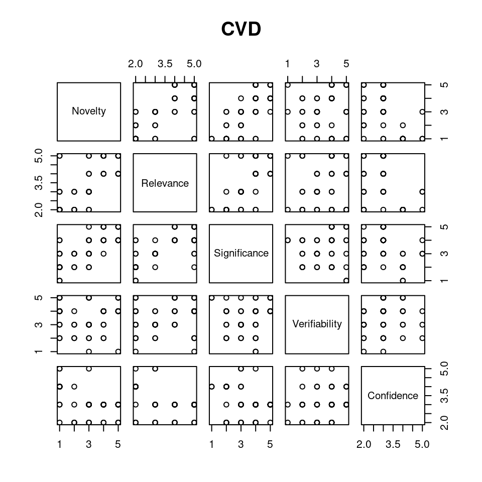

```r
plot(human_cvd %>% select(Novelty:Confidence), main = "CVD")
```

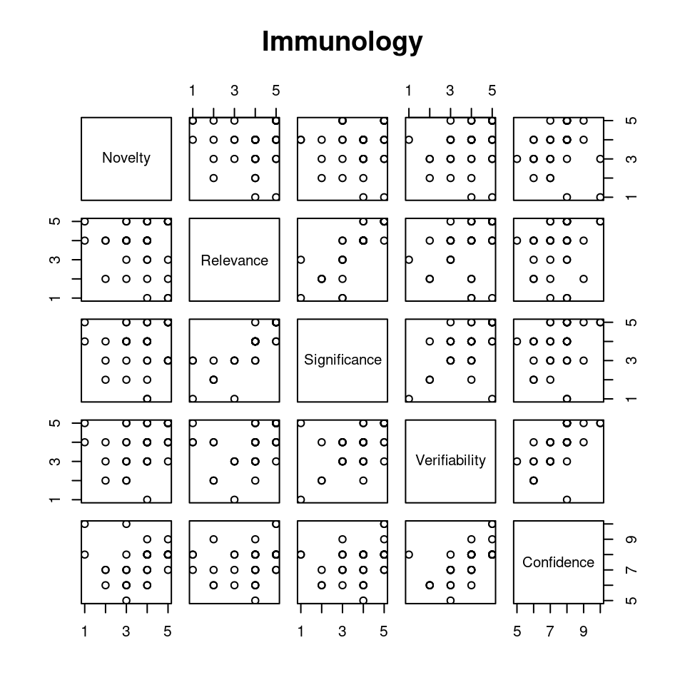

```r
plot(human_imm %>% select(Novelty:Confidence), main = "Immunology")
```

Get the data into a long format.

```r
human_long <- human %>%
    select(-Confidence_num) %>%
    group_by(topic, Hypothesis) %>%
    mutate(rater_id = row_number()) %>%
    ungroup() %>%
    pivot_longer(Novelty:Confidence, names_to = "metric", values_to = "rating") %>%
    mutate(metric_abbr = stringr::str_sub(metric, 1, 1))
```

## Visualizing Likert scales

Now we can try to plot the results.

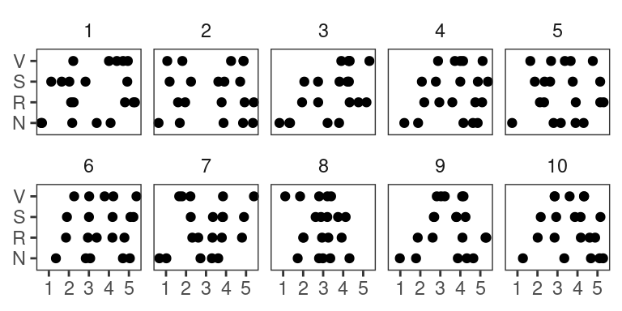

```r
# Plot by metric, facet by hypothesis
ggplot(human_long %>% filter(metric != "Confidence", topic == "CVD")) +
    aes(metric_abbr, rating) +
    geom_jitter(width = 0) +
    facet_wrap(~Hypothesis, nrow = 2) +
    coord_flip() +
    labs(x = NULL, y = NULL)
```

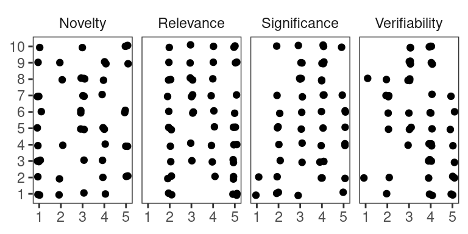

```r
# Plot by hypothesis, facet by metric
ggplot(human_long %>% filter(metric != "Confidence", topic == "CVD")) +
    aes(as.factor(Hypothesis), rating) +
    geom_jitter(width = 0.1, height = 0.1) +
    facet_wrap(~metric, nrow = 1) +
    coord_flip() +
    labs(x = NULL, y = NULL)
```

Not especially satisfying, to be honest. But we can try a stacked bar chart visualization inspired by those from the `likert` package.

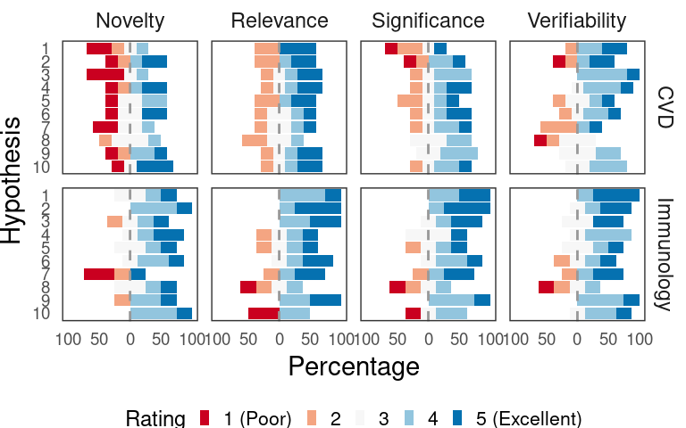

```r
likert_data <- human_long %>%
    filter(metric != "Confidence") %>%
    group_by(topic) %>%
    count(metric, Hypothesis, rating) %>%
    group_by(topic, metric, Hypothesis) %>%
    mutate(frac = n / sum(n)) %>%
    ungroup() %>%
    mutate(
        plot_value = case_when(
            rating %in% 1:2 ~ -frac,
            rating %in% 4:5 ~ frac,
            rating == 3 ~ frac / 2
        ),
        rating_label = factor(rating,
            levels = 1:5,
            labels = c("1 (Poor)", "2", "3", "4", "5 (Excellent)"),
            ordered = TRUE
        )
    ) %>%
    # Duplicate the 'neutral' rows and make their values negative
    # so that they appear on the left side of the plot
    bind_rows(
        filter(., rating == 3) %>%
            mutate(plot_value = -plot_value)
    )

plot_likert <- function(data, facet_by = "topic") {
    ggplot(data) +
        aes(
            x = plot_value,
            y = factor(Hypothesis, levels = 10:1),
            fill = rating_label
        ) +
        # Bars to the left
        geom_col(
            position = position_stack(reverse = FALSE),
            data = data %>% filter(plot_value < 0)
        ) +
        # Bars to the right
        geom_col(
            position = position_stack(reverse = TRUE),
            data = data %>% filter(plot_value > 0)
        ) +
        # Add a vertical line to mark the centre
        geom_vline(
            xintercept = 0,
            linetype = "dashed",
            colour = "grey60"
        ) +
        facet_grid(reformulate("metric", facet_by)) +
        scale_fill_brewer(
            type = "div", direction = 1, name = "Rating",
            palette = 5
        ) +
        scale_x_continuous("Percentage",
            breaks = seq(-1, 1, by = 0.5),
            labels = c(100, 50, 0, 50, 100),
            limits = c(-1, 1)
        ) +
        scale_y_discrete("Hypothesis") +
        theme(
            strip.background = element_blank(),
            legend.position = "bottom",
            panel.grid = element_blank(),
            plot.margin = margin(0, 0, 0, 0),
            axis.text = element_text(size = unit(7, "pt")),
            axis.ticks = element_blank(),
            legend.text = element_text(
                size = unit(8, "pt")
            ),
            legend.title = element_text(size = unit(9, "pt")),
            legend.margin = margin(0, 0, 0, 0),
            legend.key.size = unit(5, "pt"),
            legend.box.margin = margin(0, 0, 0, 0)
        )
}

plot_likert(likert_data)
```

**Caution**

Not implemented.

## Bayesian modelling

But an even better approach for this might be to fit a statistical model. An graded response model (a generalization of a Rasch model in item-response theory) can take the following form:

Let $Y_{ijm}$ be the ordinal rating (on a scale of 1 to 5) given by rater $i$ to hypothesis $j$ on metric $m$. The model estimates the cumulative probability $P(Y_{ijm}\leq k)$ for each rating category $k \in \{1,2,3,4\}$. Using the probit link function ($\Phi^{-1}$, the inverse of the standard normal cdf), the model is defined:

$$P(Y_{ijm} \leq k) = \Phi(\tau_k - \eta_{ijm}),$$

where the linear predictor contains the fixed and random effects:

$$\eta_{ijm} = \underbrace{\beta_m}_\text{metric effect} + \underbrace{u_i}_\text{rater effect} + \underbrace{v_{jm}}_{\substack{\text{hypo.-on-metric}\\ \text{effect}}}$$

and where $\tau_k$ are thresholds of the ordinal rating categories on the latent scale; $\beta_m$ is a fixed effect representing the average ‘quality’ or ‘easiness’ for metric $m$, $u_i \sim N(0, \sigma_u^2)$ is a random effect for rater $i$, representing their overall leniency or severity; $v_{jm} \sim N(0, \sigma_v^2)$ is the random effect for the quality of hypothesis $j$ specifically on metric $m$.

We fit a single **Bayesian cumulative ordinal mixed-effects model** for all metrics, which has the advantage (over separately modelling each metric) of pooling ratings for more robust estimates, however with the strong assumption that the effect of ‘rater leniency’ is constant across the four metrics.

```r
message("We have ", parallel::detectCores(), " cores available.")
```

```
We have 20 cores available.
```

```r
options(mc.cores = min(4, parallel::detectCores()))
```

### Model for CVD

```r
brm_cvd <- brm(
    rating ~ metric + (1 | rater_id) + (1 | metric:Hypothesis),
    data = human_long %>% filter(metric != "Confidence", topic == "CVD"),
    family = cumulative("probit"),
    seed = 123,
    file = "brm_cvd.rds"
)

summary(brm_cvd)
```

```
 Family: cumulative
  Links: mu = probit; disc = identity
Formula: rating ~ metric + (1 | rater_id) + (1 | metric:Hypothesis)
   Data: human_long %>% filter(metric != "Confidence", topi (Number of observations: 200)
  Draws: 4 chains, each with iter = 2000; warmup = 1000; thin = 1;
         total post-warmup draws = 4000

Multilevel Hyperparameters:
~metric:Hypothesis (Number of levels: 40)
              Estimate Est.Error l-95% CI u-95% CI Rhat Bulk_ESS Tail_ESS
sd(Intercept)     0.23      0.13     0.01     0.51 1.00     1068     1677

~rater_id (Number of levels: 5)
              Estimate Est.Error l-95% CI u-95% CI Rhat Bulk_ESS Tail_ESS
sd(Intercept)     1.22      0.53     0.54     2.53 1.00     1395     2193

Regression Coefficients:
                    Estimate Est.Error l-95% CI u-95% CI Rhat Bulk_ESS Tail_ESS
Intercept[1]           -1.38      0.54    -2.42    -0.27 1.00     1301     1972
Intercept[2]           -0.31      0.53    -1.32     0.80 1.00     1292     1951
Intercept[3]            0.58      0.53    -0.43     1.71 1.00     1292     1949
Intercept[4]            1.59      0.54     0.58     2.75 1.00     1304     2016
metricRelevance         0.74      0.25     0.24     1.24 1.00     3069     2426
metricSignificance      0.52      0.25     0.02     1.00 1.00     2586     2742
metricVerifiability     0.59      0.25     0.10     1.07 1.01     2919     2885

Further Distributional Parameters:
     Estimate Est.Error l-95% CI u-95% CI Rhat Bulk_ESS Tail_ESS
disc     1.00      0.00     1.00     1.00   NA       NA       NA

Draws were sampled using sampling(NUTS). For each parameter, Bulk_ESS
and Tail_ESS are effective sample size measures, and Rhat is the potential
scale reduction factor on split chains (at convergence, Rhat = 1).
```

```r
# Extract and plot the estimated parameters for hypotheses and raters
random_effects_cvd <- ranef(brm_cvd)

# Hypothesis 'quality' scores
random_effects_cvd$`metric:Hypothesis`
```

```
, , Intercept

                     Estimate Est.Error       Q2.5     Q97.5
Novelty_1        -0.174208686 0.2600932 -0.8100555 0.2050408
Novelty_10        0.192178677 0.2674922 -0.1920698 0.8609321
Novelty_2         0.098324808 0.2279781 -0.3008343 0.6343681
Novelty_3        -0.230731284 0.2869937 -0.9418240 0.1675903
Novelty_4         0.098472113 0.2340740 -0.3182797 0.6557278
Novelty_5        -0.001288264 0.2134584 -0.4516745 0.4547069
Novelty_6         0.103991858 0.2375933 -0.3384210 0.6718175
Novelty_7        -0.139371409 0.2536009 -0.7516938 0.2649301
Novelty_8         0.008096726 0.2142932 -0.4439355 0.4539571
Novelty_9         0.038783907 0.2219880 -0.4072708 0.5451447
Relevance_1       0.070909573 0.2309552 -0.3582440 0.6253969
Relevance_10      0.046418074 0.2223345 -0.3903633 0.5456073
Relevance_2       0.006227210 0.2211086 -0.4583735 0.4865676
Relevance_3       0.053520315 0.2239131 -0.3900176 0.5672490
Relevance_4       0.058409593 0.2185753 -0.3659470 0.5696934
Relevance_5       0.010101799 0.2183460 -0.4458115 0.4967464
Relevance_6      -0.050663509 0.2231571 -0.5756033 0.3612223
Relevance_7      -0.050752722 0.2163720 -0.5534184 0.3791399
Relevance_8      -0.182441019 0.2597005 -0.8221887 0.2021294
Relevance_9       0.050399603 0.2279691 -0.3906243 0.5764610
Significance_1   -0.173319453 0.2603665 -0.8025484 0.2208724
Significance_10   0.039477451 0.2220135 -0.4038634 0.5466982
Significance_2   -0.051192956 0.2190629 -0.5519859 0.3777137
Significance_3   -0.012436722 0.2230540 -0.5012015 0.4702164
Significance_4    0.097819477 0.2353543 -0.3161001 0.6564078
Significance_5   -0.037782210 0.2195514 -0.5195294 0.3945542
Significance_6    0.097732831 0.2269104 -0.3106714 0.6352560
Significance_7    0.044110765 0.2144341 -0.3764254 0.5317611
Significance_8   -0.012981185 0.2179821 -0.4979517 0.4455145
Significance_9    0.028682482 0.2162001 -0.3950287 0.5139362
Verifiability_1   0.117427039 0.2434902 -0.2944853 0.7137811
Verifiability_10  0.007781476 0.2159063 -0.4248299 0.4759452
Verifiability_2  -0.018552081 0.2187454 -0.4922789 0.4202779
Verifiability_3   0.151051337 0.2511946 -0.2406575 0.7616373
Verifiability_4   0.108786694 0.2348762 -0.2907253 0.6732105
Verifiability_5  -0.022130029 0.2185272 -0.4954176 0.4295264
Verifiability_6   0.025490253 0.2158849 -0.4065804 0.5185785
Verifiability_7  -0.097264960 0.2237372 -0.6283535 0.2884183
Verifiability_8  -0.236518881 0.2805733 -0.9217775 0.1494829
Verifiability_9  -0.031660522 0.2138983 -0.5022446 0.4011680
```

```r
# Rater 'leniency' scores
random_effects_cvd$rater_id
```

```
, , Intercept

    Estimate Est.Error        Q2.5       Q97.5
1 -1.1177497 0.5203233 -2.17680004 -0.05537351
2  0.7424988 0.5204033 -0.26208934  1.84408680
3 -0.6186062 0.5162044 -1.61661104  0.44897783
4  0.2915631 0.5142442 -0.68560434  1.39334919
5  1.0232271 0.5272035  0.01525896  2.15731689
```

We use weakly informative or flat default priors on all parameters and variance components:

```r
get_prior(brm_cvd) |> kable()
```

| prior | class | coef | group | resp | dpar | nlpar | lb | ub | source |
| --- | --- | --- | --- | --- | --- | --- | --- | --- | --- |
|  | b |  |  |  |  |  |  |  | default |
|  | b | metricRelevance |  |  |  |  |  |  | default |
|  | b | metricSignificance |  |  |  |  |  |  | default |
|  | b | metricVerifiability |  |  |  |  |  |  | default |
| student_t(3, 0, 2.5) | Intercept |  |  |  |  |  |  |  | default |
|  | Intercept | 1 |  |  |  |  |  |  | default |
|  | Intercept | 2 |  |  |  |  |  |  | default |
|  | Intercept | 3 |  |  |  |  |  |  | default |
|  | Intercept | 4 |  |  |  |  |  |  | default |
| student_t(3, 0, 2.5) | sd |  |  |  |  |  | 0 |  | default |
|  | sd |  | metric:Hypothesis |  |  |  |  |  | default |
|  | sd | Intercept | metric:Hypothesis |  |  |  |  |  | default |
|  | sd |  | rater_id |  |  |  |  |  | default |
|  | sd | Intercept | rater_id |  |  |  |  |  | default |

### Model for immunology

```r
brm_imm <- brm(
    rating ~ metric + (1 | rater_id) + (1 | metric:Hypothesis),
    data = human_long %>% filter(metric != "Confidence", topic == "Immunology"),
    family = cumulative("probit"),
    seed = 123,
    file = "brm_immunology.rds"
)

summary(brm_imm)
```

```
 Family: cumulative
  Links: mu = probit; disc = identity
Formula: rating ~ metric + (1 | rater_id) + (1 | metric:Hypothesis)
   Data: human_long %>% filter(metric != "Confidence", topi (Number of observations: 160)
  Draws: 4 chains, each with iter = 2000; warmup = 1000; thin = 1;
         total post-warmup draws = 4000

Multilevel Hyperparameters:
~metric:Hypothesis (Number of levels: 40)
              Estimate Est.Error l-95% CI u-95% CI Rhat Bulk_ESS Tail_ESS
sd(Intercept)     0.51      0.16     0.18     0.83 1.00     1087     1365

~rater_id (Number of levels: 4)
              Estimate Est.Error l-95% CI u-95% CI Rhat Bulk_ESS Tail_ESS
sd(Intercept)     0.87      0.53     0.29     2.30 1.00     1168     1926

Regression Coefficients:
                    Estimate Est.Error l-95% CI u-95% CI Rhat Bulk_ESS Tail_ESS
Intercept[1]           -1.71      0.52    -2.70    -0.64 1.00     1461     1587
Intercept[2]           -1.12      0.50    -2.07    -0.10 1.00     1457     1532
Intercept[3]           -0.38      0.49    -1.31     0.63 1.00     1435     1595
Intercept[4]            0.76      0.50    -0.14     1.82 1.00     1466     1607
metricRelevance         0.13      0.34    -0.55     0.80 1.00     1986     2504
metricSignificance      0.10      0.34    -0.58     0.78 1.00     2319     2579
metricVerifiability     0.16      0.34    -0.50     0.84 1.00     2251     2328

Further Distributional Parameters:
     Estimate Est.Error l-95% CI u-95% CI Rhat Bulk_ESS Tail_ESS
disc     1.00      0.00     1.00     1.00   NA       NA       NA

Draws were sampled using sampling(NUTS). For each parameter, Bulk_ESS
and Tail_ESS are effective sample size measures, and Rhat is the potential
scale reduction factor on split chains (at convergence, Rhat = 1).
```

```r
# Extract and plot the estimated parameters for hypotheses and raters
random_effects_imm <- ranef(brm_imm)

# Hypothesis 'quality' scores
random_effects_imm$`metric:Hypothesis`
```

```
, , Intercept

                    Estimate Est.Error       Q2.5     Q97.5
Novelty_1        -0.01714607 0.3733817 -0.7885958 0.7220313
Novelty_10        0.18811948 0.4073772 -0.5708601 1.0623589
Novelty_2         0.21941148 0.4007942 -0.5123484 1.0950897
Novelty_3        -0.10259792 0.3962874 -0.9389457 0.6507671
Novelty_4         0.25739632 0.4007957 -0.4769289 1.0893964
Novelty_5        -0.01583872 0.3875008 -0.7986799 0.7422470
Novelty_6         0.10174314 0.3770353 -0.6448195 0.8565316
Novelty_7        -0.61499737 0.4418887 -1.5825764 0.1442686
Novelty_8        -0.03846695 0.3835545 -0.8229786 0.7290512
Novelty_9         0.01422520 0.3814932 -0.7456399 0.7865617
Relevance_1       0.16260877 0.3893897 -0.5787430 0.9757335
Relevance_10     -0.61918085 0.4394792 -1.5618654 0.1312227
Relevance_2       0.51607535 0.4520130 -0.2452689 1.5215085
Relevance_3       0.33627516 0.4063849 -0.4228695 1.2041623
Relevance_4      -0.20754564 0.3806156 -1.0055346 0.5064340
Relevance_5      -0.16230226 0.3891687 -0.9755119 0.5729635
Relevance_6       0.20910494 0.3972571 -0.5532194 1.0449688
Relevance_7       0.11705229 0.3913395 -0.6269293 0.9212945
Relevance_8      -0.63442093 0.4453027 -1.5900412 0.1397700
Relevance_9       0.33260059 0.4148600 -0.3982563 1.1940518
Significance_1    0.35027789 0.4206193 -0.4137849 1.2424178
Significance_10  -0.41901108 0.4036512 -1.2910124 0.3160683
Significance_2    0.52009923 0.4590361 -0.2727464 1.5115439
Significance_3    0.21072601 0.4141468 -0.5457782 1.0829526
Significance_4   -0.22435823 0.3846736 -1.0125483 0.5086315
Significance_5   -0.15885157 0.3845575 -0.9596277 0.5672138
Significance_6    0.05149650 0.3884395 -0.7199727 0.8492237
Significance_7    0.12869750 0.3950031 -0.6260680 0.9501686
Significance_8   -0.61304458 0.4398538 -1.5600618 0.1425085
Significance_9    0.17413130 0.3856669 -0.5694239 0.9828561
Verifiability_1   0.51385534 0.4346423 -0.2358371 1.4613383
Verifiability_10  0.02928033 0.3842312 -0.7214610 0.8472767
Verifiability_2   0.20474652 0.4045138 -0.5503377 1.0787975
Verifiability_3   0.07410771 0.3857263 -0.6646271 0.8928726
Verifiability_4  -0.16376665 0.3766157 -0.9633135 0.5477089
Verifiability_5  -0.09497502 0.3854926 -0.8847993 0.6616186
Verifiability_6  -0.17520421 0.3841025 -0.9768839 0.5349562
Verifiability_7   0.10674152 0.3975771 -0.6650187 0.9194357
Verifiability_8  -0.63516765 0.4498972 -1.5801917 0.1539082
Verifiability_9   0.15131648 0.3966486 -0.6142805 0.9872977
```

```r
# Rater 'leniency' scores
random_effects_imm$rater_id
```

```
, , Intercept

      Estimate Est.Error        Q2.5     Q97.5
1  0.873628515 0.4718731  0.06989941 1.9523065
2  0.007396534 0.4516199 -0.83901421 1.0069429
3 -0.311557314 0.4487088 -1.21167982 0.6700423
4 -0.113443828 0.4419953 -0.94653638 0.8395621
```

## Bayesian inference

From this fitted model we obtain the following inferences. It’s handy to use `tidybayes` for this, and to get the right variable names we use `variables(model)` (output omitted).

```r
variables(brm_cvd) # check variable name syntax for spread_draws
```

### Hypothesis quality scores by metric

For cardiovascular disease:

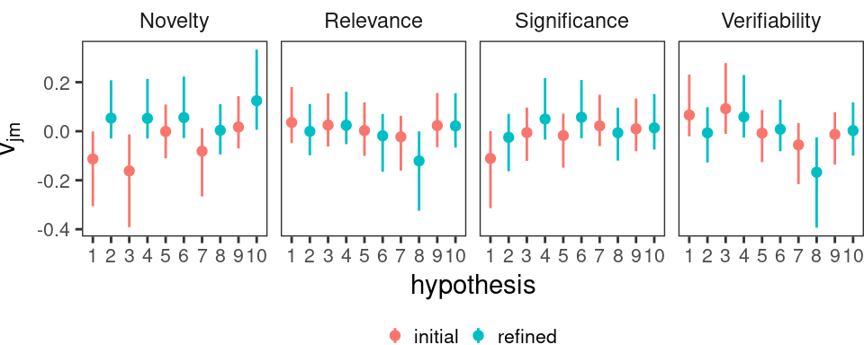

```r
# Helper functions for posterior credible intervals
# e.g. 50%, 80%, 95%
qlower <- function(x) quantile(x, 0.25)
qupper <- function(x) quantile(x, 0.75)

prepare_hypothesis_by_metric <- function(model, combo) {
    model %>%
        tidybayes::spread_draws(`r_metric:Hypothesis`[combo, term]) %>%
        tidyr::separate_wider_delim(combo, "_", names = c("metric", "hypothesis")) %>%
        group_by(metric, hypothesis) %>% # .chain
        summarise(
            lower = qlower(`r_metric:Hypothesis`),
            upper = qupper(`r_metric:Hypothesis`),
            median = median(`r_metric:Hypothesis`),
            .groups = "drop"
        ) %>%
        mutate(
            hypothesis = reorder(hypothesis, as.numeric(as.character(hypothesis))),
            refined = if_else(as.numeric(as.character(hypothesis)) %% 2 == 0, "refined", "initial")
        )
}

hypothesis_by_metric <- list(CVD = brm_cvd, Immunology = brm_imm) %>%
    map(prepare_hypothesis_by_metric) %>%
    bind_rows(.id = "topic")

plot_hypothesis_by_metric <- function(data) {
    ggplot(data) +
        aes(hypothesis, median, ymin = lower, ymax = upper, colour = refined) +
        geom_linerange() +
        geom_point() +
        facet_wrap(~metric, nrow = 1) +
        ylab(expression(v[jm])) +
        theme(
            legend.position = "bottom",
            panel.grid = element_blank(),
            plot.margin = margin(0, 0, 0, 0),
            axis.text = element_text(size = unit(8, "pt")),
            legend.text = element_text(
                size = unit(8, "pt")
            ),
            legend.title = element_text(size = unit(9, "pt")),
            legend.margin = margin(0, 0, 0, 0),
            legend.key.size = unit(5, "pt"),
            legend.box.margin = margin(0, 0, 0, 0)
        ) +
        scale_colour_discrete(NULL)
}

plot_hypothesis_by_metric2 <- function(data) {
    ggplot(data %>% mutate(hypothesis = factor(hypothesis, levels = 10:1))) +
        aes(hypothesis, median, ymin = lower, ymax = upper, colour = refined) +
        geom_linerange() +
        geom_point() +
        # scale_x_discrete(breaks = seq(2, 10, by = 2)) +
        ylab("hypothesis effect, by metric") +
        coord_flip() +
        facet_wrap(~metric, nrow = 1) +
        theme(
            legend.position = "bottom",
            panel.grid = element_blank(),
            plot.margin = margin(0, 0, 0, 0),
            axis.text = element_text(size = unit(8, "pt")),
            legend.text = element_text(
                size = unit(8, "pt")
            ),
            legend.title = element_text(size = unit(9, "pt")),
            legend.margin = margin(0, 0, 0, 0),
            legend.key.size = unit(5, "pt"),
            legend.box.margin = margin(0, 0, 0, 0)
        ) +
        scale_colour_discrete(NULL)
}

plot_hypothesis_by_metric(hypothesis_by_metric %>% filter(topic == "CVD"))
```

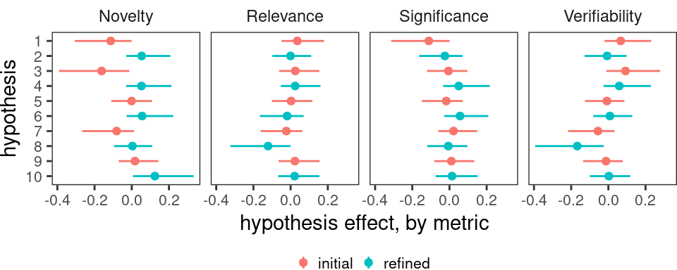

```r
plot_hypothesis_by_metric2(hypothesis_by_metric %>% filter(topic == "CVD"))
```

For immunology:

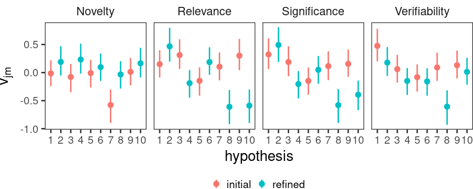

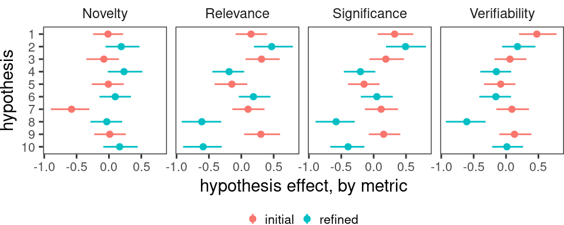

For both:

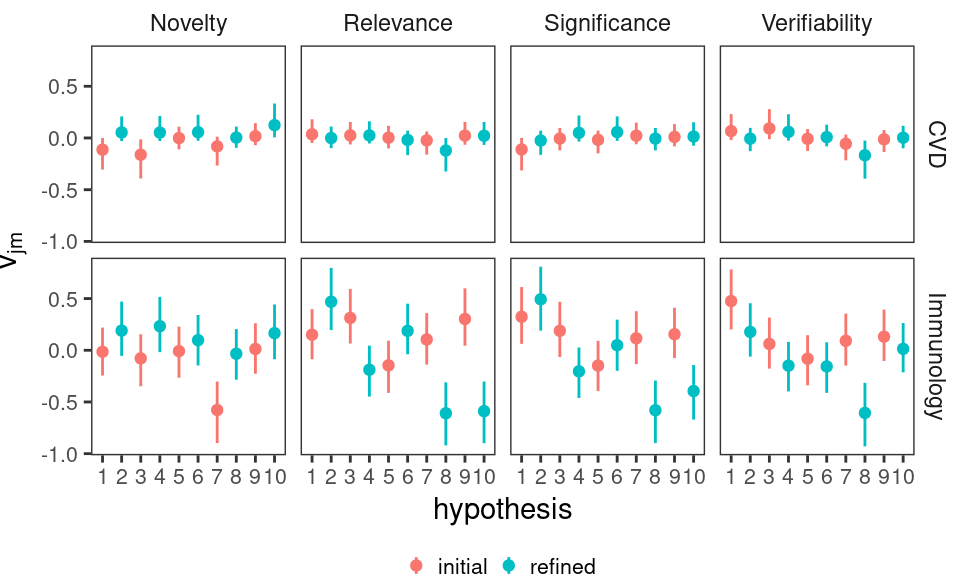

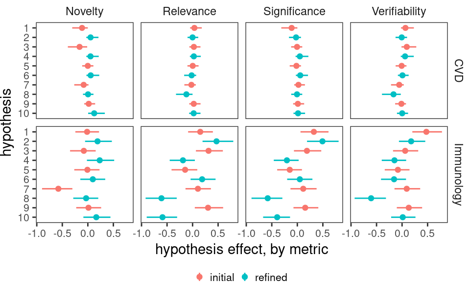

### Rater leniency/severity

For CVD:

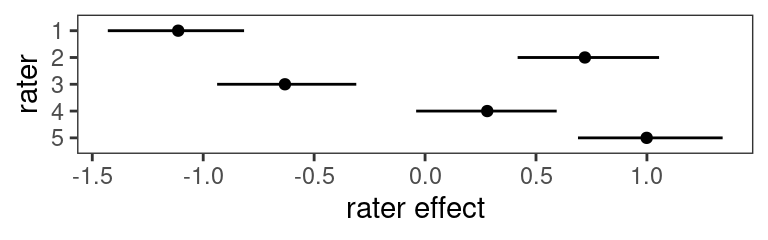

```r
prepare_rater_leniency <- function(data) {
    data %>%
        spread_draws(r_rater_id[rater, term]) %>%
        group_by(rater) %>%
        summarise(
            lower = qlower(r_rater_id),
            upper = qupper(r_rater_id),
            median = median(r_rater_id),
            .groups = "drop"
        ) %>%
        mutate(rater = reorder(rater, as.numeric(rater), decreasing = TRUE))
}

rater_leniency <- list(CVD = brm_cvd, Immunology = brm_imm) %>%
    map(prepare_rater_leniency) %>%
    bind_rows(.id = "topic")

ggplot(rater_leniency %>% filter(topic == "CVD")) +
    aes(rater, median, ymin = lower, ymax = upper) +
    geom_linerange() +
    geom_point() +
    ylab("rater effect") +
    coord_flip()
```

For immunology:

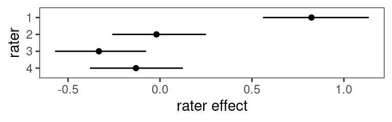

For both:

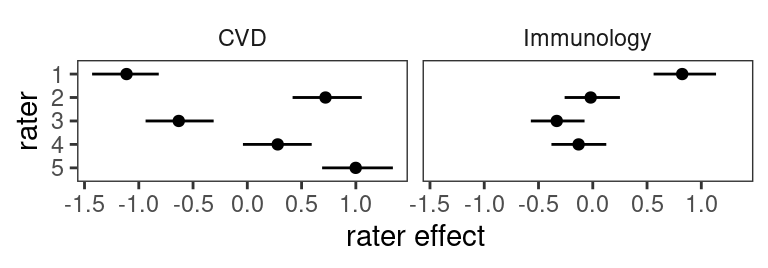

### Selected hypotheses

We can also use `brms::posterior_predict()` or `tidybayes::add_predicted_draws()` to generate the expected distribution of ratings for selected hypotheses of interest, for example the best and worst for novelty. We would expect the ‘best’ hypothesis to show a high probability of receiving 4s or 5s, and the ‘worst’ hypothesis might show a high(er) probability of receiving 1s and 2s.

**Caution**

Not implemented.